# Mexicanos en el extranjero

Carlo Federico Muro Lajas

22/12/2020

### Este proyecto se enfocará en realizar gráficas a partir de matrices para analizar los países a los que los mexicanos suelen emigrar más. Posteriormente ubicaremos los países correspondientes en un mapa. Estos datos fueron recopilados del Instituto de los Mexicanos en el Exterior perteneciente al Gobierno de México siendo el último año registrado el 2017.

### Es importante establecer como primer paso las librerías que deseas utilizar en el proyecto.

```r
library(ggmap)
```

### Después realizamos una matriz que contenga los tres países con la mayor cantidad de mexicanos viviendo en el continente Americano.

## 1.América

```r
eu<-(11517375)
ca<-(128485)
bo<-(9411)
am<-matrix(c(eu,ca,bo),nrow=1)
colnames(am)=c("EUA","Canadá","Bolivia")
rownames(am)=c("Mexicanos")
am
```

```
##                EUA Canadá Bolivia
## Mexicanos 11517375 128485    9411
```

### Ahora realizaremos una gráfica de barras sencilla para ver la diferencia entre los tres países.

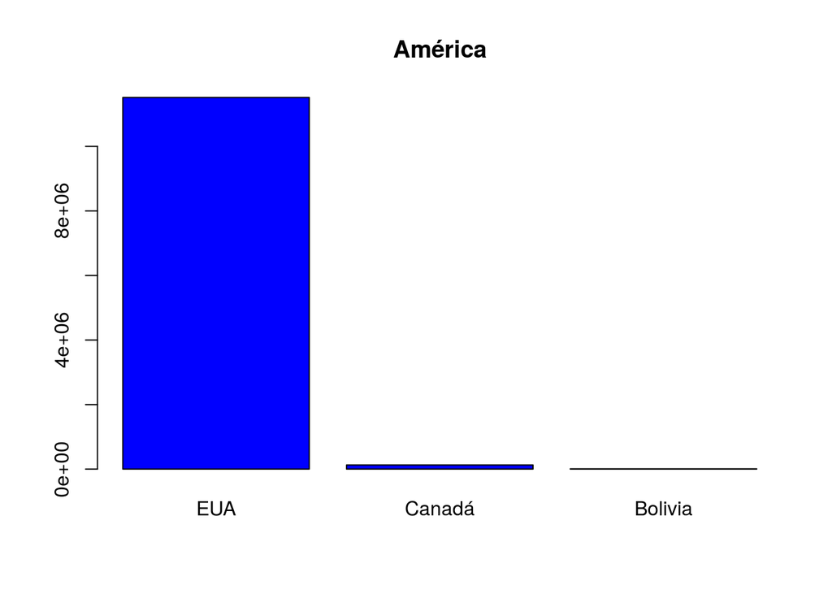

```r
barplot(am, main="América", col= "blue")
```

### Posteriormente ubicaremos la capital de cada uno de estos países, así como la de México para poder visualizar de una mejor manera la lejanía de cada país.

```r
EUA<-c(-77.03637,38.89511)
Canadá<-c(-75.69812,45.41117)
Bolivia<-c(-68.15,-16.5)
México<-c(-99.12766,19.42847)
America<-rbind(EUA,Canadá,Bolivia,México)
colnames(America)<-c("Longitud","Latitud")
America
```

```
##          Longitud   Latitud
## EUA     -77.03637  38.89511
## Canadá  -75.69812  45.41117
## Bolivia -68.15000 -16.50000
## México  -99.12766  19.42847
```

### Se grafica un dataframe que nos permite realizar otro tipo de gráficas.

```r
America<-data.frame(America)
America
```

```
##          Longitud   Latitud
## EUA     -77.03637  38.89511
## Canadá  -75.69812  45.41117
## Bolivia -68.15000 -16.50000
## México  -99.12766  19.42847
```

### Con la función qmplot graficaremos los 4 puntos previamente establecidos.

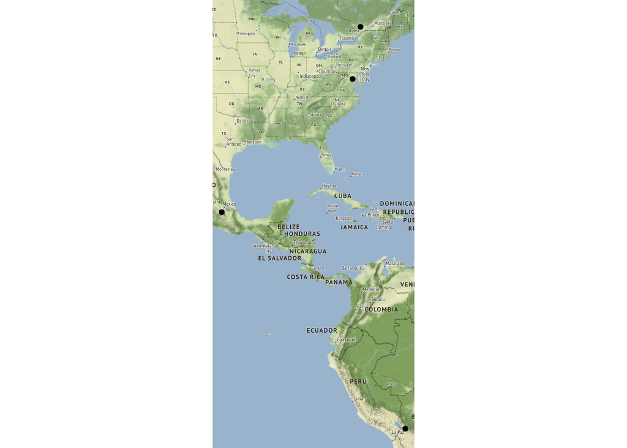

```r
qmplot(Longitud, Latitud, data=America)
```

### Procederemos a hacer lo mismo para cada continente.

## 2.Europa

```r
es<-(52524)
ru<-(16000)
al<-(15813)
eu<-matrix(c(es,ru,al),nrow=1)
colnames(eu)=c("España","Reino Unido","Alemania")
rownames(eu)=c("Mexicanos")
eu
```

```
##           España Reino Unido Alemania
## Mexicanos  52524       16000    15813
```

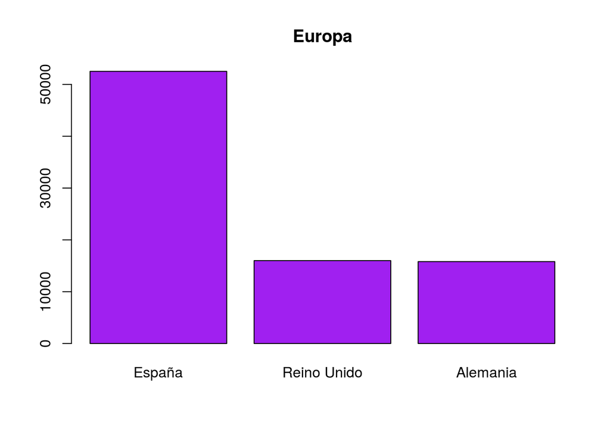

```r
barplot(eu, main="Europa", col= "purple")
```

```r
España<-c(-3.70256,40.4165)
ReinoUnido<-c(-0.12574,51.50853)
Alemania<-c(13.41053,52.52437)
México<-c(-99.12766,19.42847)
Europa<-rbind(España,ReinoUnido,Alemania,México)
colnames(Europa)<-c("Longitud","Latitud")
Europa
```

```
##             Longitud  Latitud
## España      -3.70256 40.41650
## ReinoUnido  -0.12574 51.50853
## Alemania    13.41053 52.52437
## México     -99.12766 19.42847
```

```r
Europa<-data.frame(Europa)
Europa
```

```
##             Longitud  Latitud
## España      -3.70256 40.41650
## ReinoUnido  -0.12574 51.50853
## Alemania    13.41053 52.52437
## México     -99.12766 19.42847
```

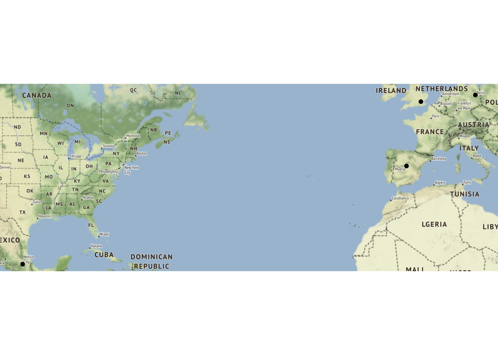

```r
qmplot(Longitud, Latitud, data=Europa)
```

## 3. Asia

```r
is<-(5000)
ch<-(3005)
ja<-(2327)
as<-matrix(c(is,ch,ja),nrow=1)
colnames(as)=c("Israel","China","Japón")
rownames(as)=c("Mexicanos")
as
```

```
##           Israel China Japón
## Mexicanos   5000  3005  2327
```

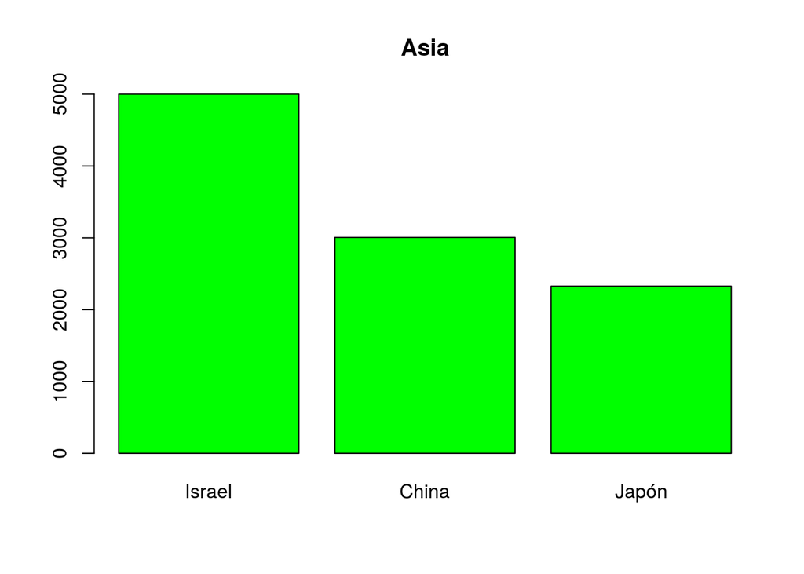

```r
barplot(as, main="Asia", col= "green")
```

```r
Israel<-c(34.78057,32.08088 )
China<-c(116.39723,39.9075)
Japón<-c(139.69171,35.6895 )
México<-c(-99.12766,19.42847)
Asia<-rbind(Israel,China,Japón,México)
colnames(Asia)<-c("Longitud","Latitud")
Asia
```

```
##         Longitud  Latitud
## Israel  34.78057 32.08088
## China  116.39723 39.90750
## Japón  139.69171 35.68950
## México -99.12766 19.42847
```

```r
Asia<-data.frame(Asia)
Asia
```

```
##         Longitud  Latitud
## Israel  34.78057 32.08088
## China  116.39723 39.90750
## Japón  139.69171 35.68950
## México -99.12766 19.42847
```

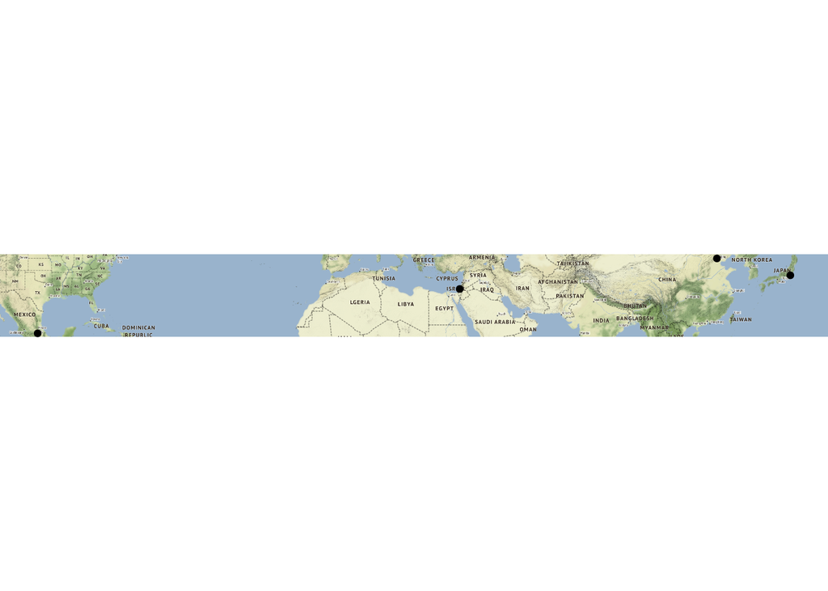

```r
qmplot(Longitud, Latitud, data=Asia)
```

## 4. Oceanía

```r
au<-(4871)
nz<-(1593)
pg<-(1)
oc<-matrix(c(au,nz,pg),nrow=1)
colnames(oc)=c("Australia","Nueva Zelanda","Papúa Nueva Guinea")
rownames(oc)=c("Mexicanos")
oc
```

```
##           Australia Nueva Zelanda Papúa Nueva Guinea
## Mexicanos      4871          1593                  1
```

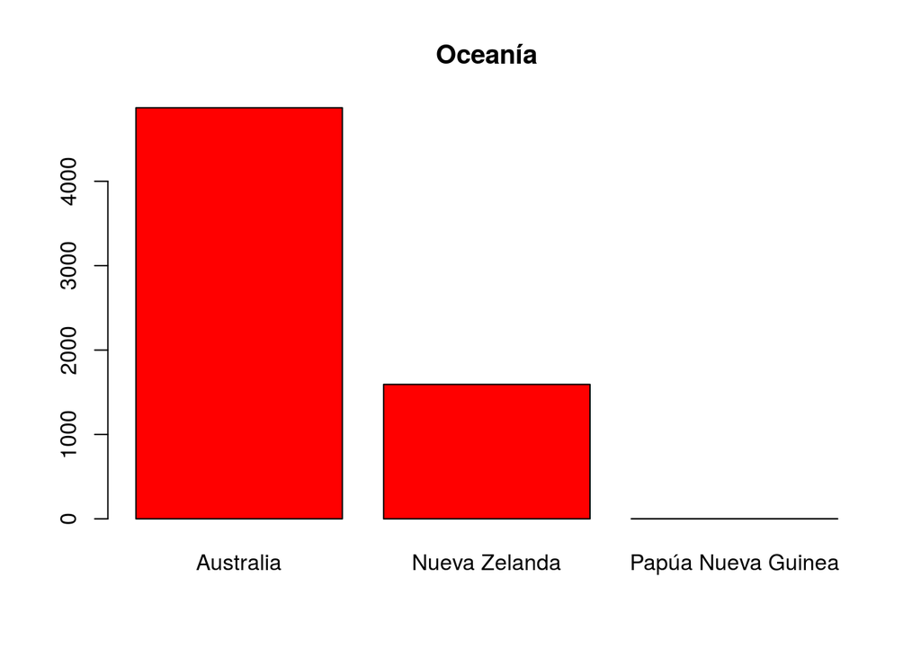

```r
barplot(oc, main="Oceanía", col= "red")
```

```r
Australia<-c(149.12807,-35.28346)
NuevaZelanda<-c(174.77557,-41.28664)
PapúaNuevaGuinea<-c(147.15089,-9.47723)
México<-c(-99.12766,19.42847)
Oceanía<-rbind(Australia,NuevaZelanda,PapúaNuevaGuinea,México)
colnames(Oceanía)<-c("Longitud","Latitud")
Oceanía
```

```
##                   Longitud   Latitud
## Australia        149.12807 -35.28346
## NuevaZelanda     174.77557 -41.28664
## PapúaNuevaGuinea 147.15089  -9.47723
## México           -99.12766  19.42847
```

```r
Oceanía<-data.frame(Oceanía)
Oceanía
```

```
##                   Longitud   Latitud
## Australia        149.12807 -35.28346
## NuevaZelanda     174.77557 -41.28664
## PapúaNuevaGuinea 147.15089  -9.47723
## México           -99.12766  19.42847
```

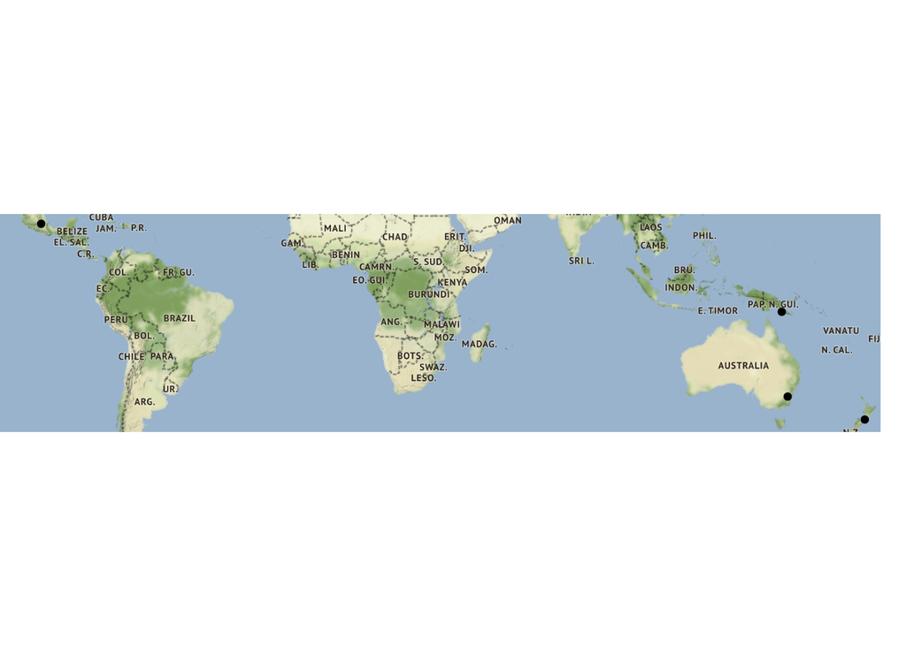

```r
qmplot(Longitud, Latitud, data=Oceanía)
```

## 5. África

```r
sa<-(235)
eg<-(162)
ke<-(156)
af<-matrix(c(sa,eg,ke),nrow=1)
colnames(af)=c("Sudáfrica","Egipto","Kenia")
rownames(af)=c("Mexicanos")
af
```

```
##           Sudáfrica Egipto Kenia
## Mexicanos       235    162   156
```

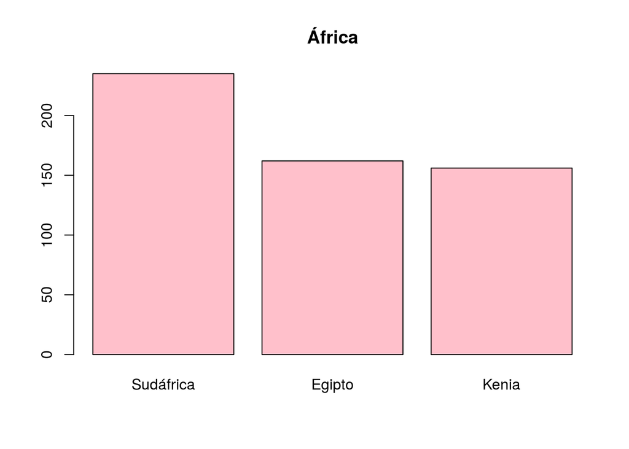

```r
barplot(af, main="África", col= "pink")
```

```r
Sudáfrica<-c(28.18783,-25.74486)
Egipto<-c(31.24967,30.06263 )
Kenia<-c(36.81667,-1.28333)
México<-c(-99.12766,19.42847)
África<-rbind(Sudáfrica,Egipto,Kenia,México)
colnames(África)<-c("Longitud","Latitud")
África
```

```
##            Longitud   Latitud
## Sudáfrica  28.18783 -25.74486
## Egipto     31.24967  30.06263
## Kenia      36.81667  -1.28333
## México    -99.12766  19.42847
```

```r
África<-data.frame(África)
África
```

```
##            Longitud   Latitud
## Sudáfrica  28.18783 -25.74486
## Egipto     31.24967  30.06263
## Kenia      36.81667  -1.28333
## México    -99.12766  19.42847
```

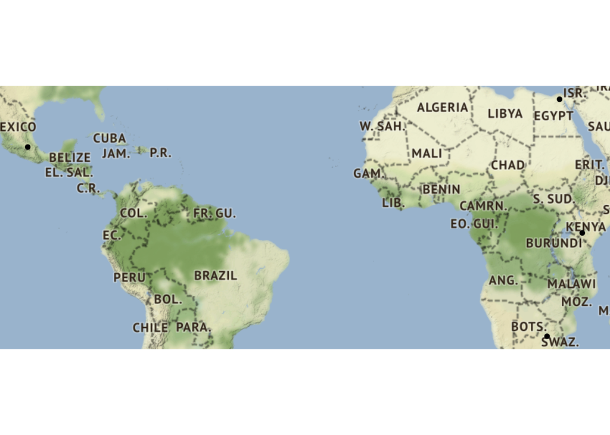

```r
qmplot(Longitud, Latitud, data=África)
```

### Por último les dejo un video explicándoles más a detalle el código para que puedan realizar proyectos similares.

[video not shown]